[figure not shown]

Capa

## Trabalho Bilionários

### Objetivo dos trabalhos

Distribuição de Riqueza por Categoria e Indústria: Identificar a distribuição de riqueza entre diferentes categorias e indústrias para entender onde está concentrada a maior parte da riqueza.

Análise Geográfica: Investigar a distribuição geográfica dos bilionários e sua correlação com fatores como o PIB, expectativa de vida, etc.

Idade e Riqueza: Examinar como a idade dos bilionários se correlaciona com sua riqueza, explorando se existe alguma tendência específica em relação à idade e ao sucesso financeiro.

Gênero e Sucesso nos Negócios: Analisar a representação de gênero entre os bilionários e como isso se relaciona com o sucesso nos negócios.

Autoconstruídos vs. Herança de Riqueza: Investigar quantos bilionários construíram sua fortuna do zero e quantos herdaram sua riqueza, e como esses dois grupos se comparam.

```r
library(tidyverse)
```

```r
library(ggplot2)
library(readr)
library(papaja)
library(dplyr)
library(knitr)
library(scales)
bilionario <- read.csv( "Billionaires Statistics Dataset.csv", sep = ",")
```

```r
# Contando a quantidade de bilionários self made e não self made
contagem_selfmade <- sum(bilionario$selfMade == TRUE)
contagem_nao_selfmade <- sum(bilionario$selfMade == FALSE)

# Mostrando os resultados
print(contagem_selfmade)
```

```
## [1] 1812
```

```r
print(contagem_nao_selfmade)
```

```
## [1] 828
```

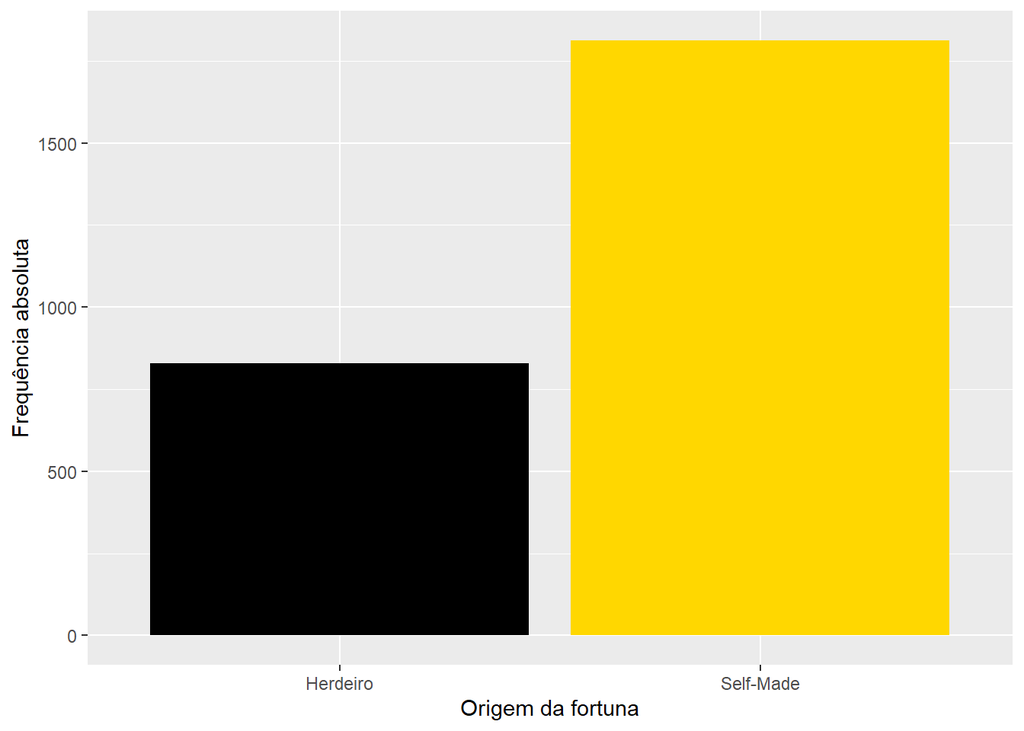

```r
# Gráficos de barras
bilionario$color <- ifelse(bilionario$selfMade == TRUE, "gold", "black")

ggplot(data = bilionario, aes(x = selfMade, fill = color)) +
  geom_bar() +
  labs(x = "Origem da fortuna", y = "Frequência absoluta") +
  scale_x_discrete(labels = c("Herdeiro", "Self-Made")) +
  scale_fill_identity()
```

Comparação relativa

[figure not shown]

```r
# Transformando a coluna 'selfMade' para fator para facilitar a visualização
bilionario$selfMade <- factor(bilionario$selfMade, labels = c("Herdeiro", "Self-Made"))

# Criando o gráfico de barras
ggplot(data = bilionario, aes(x = selfMade, fill = gender)) +
  geom_bar(position = "fill") +
  labs(x = "Origem da fortuna", y = "Frequência relativa",  fill = "Genêro") +
  scale_fill_manual(values = c("gold", "black"), labels = c("Homem", "Mulher")) +
  scale_x_discrete(labels = c("Herdeiro", "Self-Made"))
```

```
## Defaulting to continuous.
```

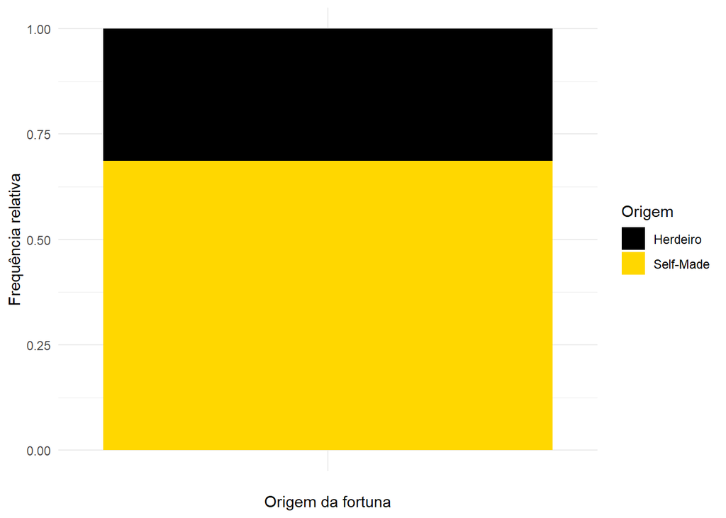

```r
# Calculando a frequência relativa
freq_rel <- prop.table(table(bilionario$selfMade))

# Criando o gráfico de barras
ggplot(data = data.frame(origem = names(freq_rel), freq_rel), aes(y = "", x = freq_rel, fill = origem)) +
  geom_bar(stat = "identity", width = 1) +
  labs(x = "Frequência relativa", y = "Origem da fortuna", fill = "Origem") +
  scale_fill_manual(values = c("black", "gold"), labels = c("Herdeiro", "Self-Made")) +
  theme_minimal() +
  coord_flip()
```

## Quantidade de bilionários por indústria

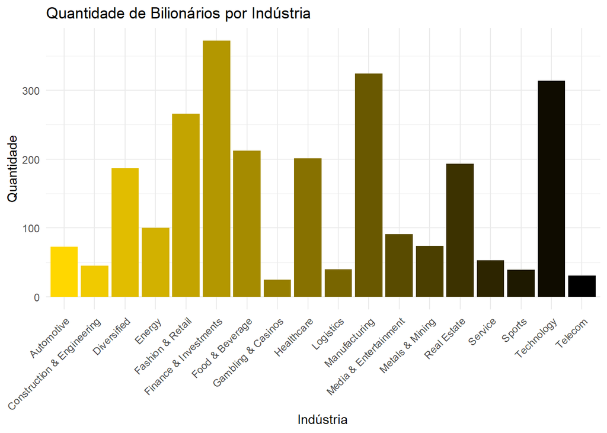

```r
# Convertendo a coluna 'category' para fator/categórica
bilionario$category <- as.factor(bilionario$category)

# Criando uma paleta de cores gradativa de dourado a preto
cores <- colorRampPalette(c("gold", "black"))(length(levels(bilionario$category)))

# Criando o gráfico de barras com a paleta de cores gradativa
grafico <- ggplot(bilionario, aes(x = category, fill = category)) +
  geom_bar() +
  labs(title = "Quantidade de Bilionários por Indústria", x = "Indústria", y = "Quantidade") +
  scale_fill_manual(values = cores) +  # Usando a paleta de cores definida
  theme_minimal() +
  theme(axis.text.x = element_text(angle = 45, hjust = 1)) +
  guides(fill = FALSE)
#Imprimindo o gráfico
print(grafico)
```

```r
# Calculando a frequência de bilionários por categoria e gênero
freq_table <- bilionario %>%
  group_by(category, gender) %>%
  summarise(count = n()) %>%
  arrange(category)
```

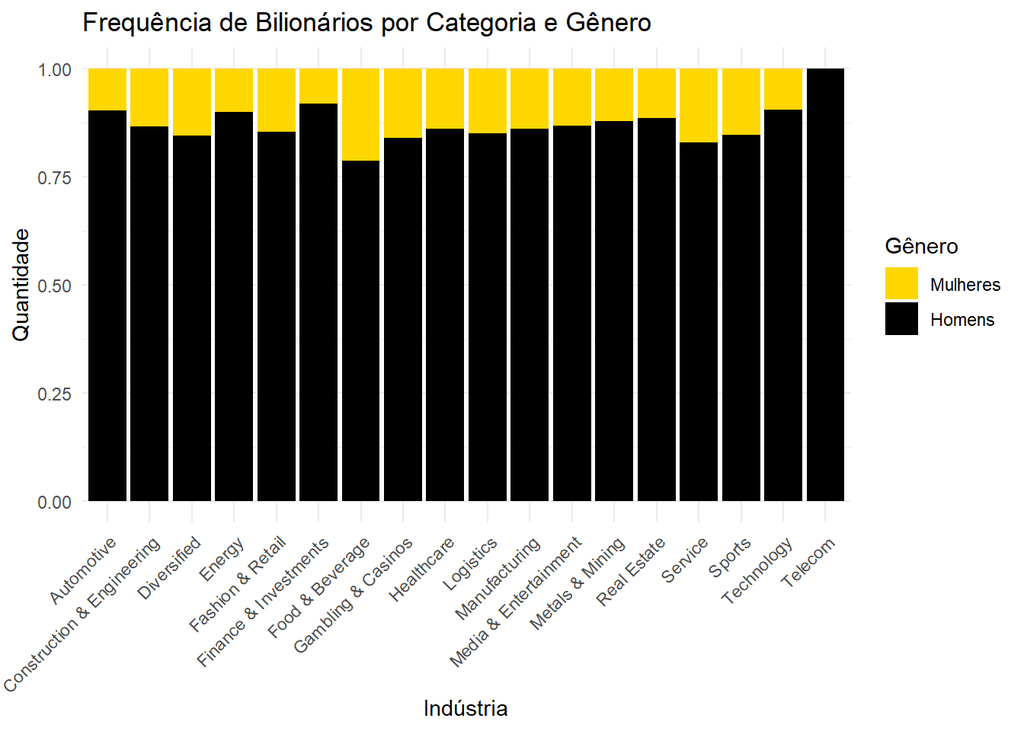

```r
# Criando o gráfico de barras
grafico_freq <- ggplot(freq_table, aes(x = category, y = count, fill = gender)) +
  geom_bar(stat = "identity", position = "fill") +
  labs(title = "Frequência de Bilionários por Categoria e Gênero", x = "Indústria", y = "Quantidade", fill = "Gênero") +
  theme_minimal() +
  theme(axis.text.x = element_text(angle = 45, hjust = 1)) +
  scale_fill_manual(values = c("gold", "black"), labels = c("Mulheres", "Homens"))  # Defina as cores desejadas para cada gênero
print(grafico_freq)
```

```r
# Calculando a frequência de bilionários por categoria e gênero
freq_table <- bilionario %>%
  group_by(category, selfMade) %>%
  summarise(count = n()) %>%
  arrange(category)
```

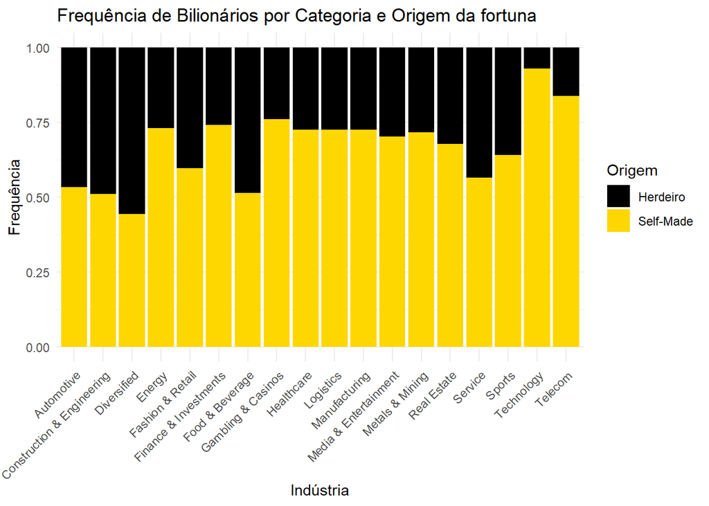

```r
# Criando o gráfico de barras
grafico_freq <- ggplot(freq_table, aes(x = category, y = count, fill = selfMade)) +
  geom_bar(stat = "identity", position = "fill") +
  labs(title = "Frequência de Bilionários por Categoria e Origem da fortuna", x = "Indústria", y = "Frequência", fill = "Origem") +
  theme_minimal() +
  theme(axis.text.x = element_text(angle = 45, hjust = 1)) +
  scale_fill_manual(values = c("black", "gold"), labels = c("Herdeiro", "Self-Made"))  # Defina as cores desejadas para cada gênero
print(grafico_freq)
```

```r
#Tabela
freq_table <- table(bilionario$selfMade, bilionario$category)

# Visualizando a tabela
print(freq_table)
```

```
##
##             Automotive Construction & Engineering Diversified Energy
##   Herdeiro          34                         22         104     27
##   Self-Made         39                         23          83     73
##
##             Fashion & Retail Finance & Investments Food & Beverage
##   Herdeiro               107                    96             103
##   Self-Made              159                   276             109
##
##             Gambling & Casinos Healthcare Logistics Manufacturing
##   Herdeiro                   6         55        11            89
##   Self-Made                 19        146        29           235
##
##             Media & Entertainment Metals & Mining Real Estate Service Sports
##   Herdeiro                     27              21          62      23     14
##   Self-Made                    64              53         131      30     25
##
##             Technology Telecom
##   Herdeiro          22       5
##   Self-Made        292      26
```

```r
# Tabela bilionario x indústria
# Criar a tabela de frequência das categorias
freq_categoria <- table(bilionario$category)

# Mostrar a tabela de frequência das categorias
print(freq_categoria)
```

```
##
##                 Automotive Construction & Engineering
##                         73                         45
##                Diversified                     Energy
##                        187                        100
##           Fashion & Retail      Finance & Investments
##                        266                        372
##            Food & Beverage         Gambling & Casinos
##                        212                         25
##                 Healthcare                  Logistics
##                        201                         40
##              Manufacturing      Media & Entertainment
##                        324                         91
##            Metals & Mining                Real Estate
##                         74                        193
##                    Service                     Sports
##                         53                         39
##                 Technology                    Telecom
##                        314                         31
```

## Idade dos bilionários e seus patrimônios em dólares

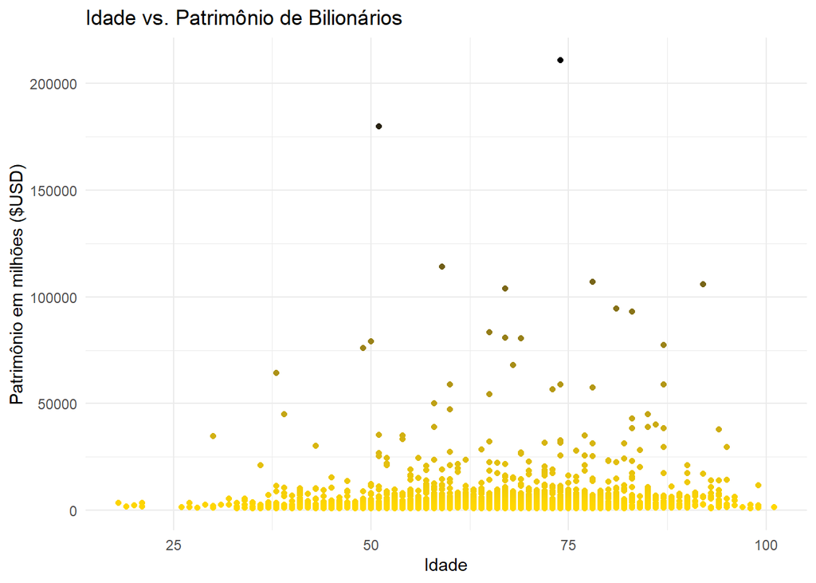

```r
# Criando gráfico de dispersão
patrimonio_idade <- ggplot(bilionario, aes(x = age, y = finalWorth)) +
  geom_point(aes(color = finalWorth), size = 1.5) +
  labs(title = "Idade vs. Patrimônio de Bilionários", x = "Idade", y = "Patrimônio em milhões ($USD)") +
  theme_minimal() +
  scale_color_gradient(low = "gold", high = "black") +
  guides(color = FALSE)
#Imprimindo o gráfico
print(patrimonio_idade)
```

Correlação não-linear entre idade e patrimônio de bilionários para se calcular o coeficiente de correlação deve ser utilizado o coeficiente de correlação de Spearman

```r
# Criando o novo dataframe com as colunas 'finalWorth' e 'age'
bilionariospearman <- data.frame(
  finalWorth = as.numeric(bilionario$finalWorth),
  age = as.numeric(bilionario$age)
)

 #Removendo NA em age
sum(is.na(bilionariospearman$finalWorth))
```

```
## [1] 0
```

```r
sum(is.na(bilionariospearman$age))
```

```
## [1] 65
```

```r
bilionariospearman <- bilionariospearman[!is.na(bilionariospearman$age), ]

# Calculando a correlação de Spearman
correlacao_spearman <- cor(bilionariospearman$finalWorth, bilionariospearman$age, method = "spearman")

# Exibindo o resultado
print(correlacao_spearman)
```

```
## [1] 0.1440389
```

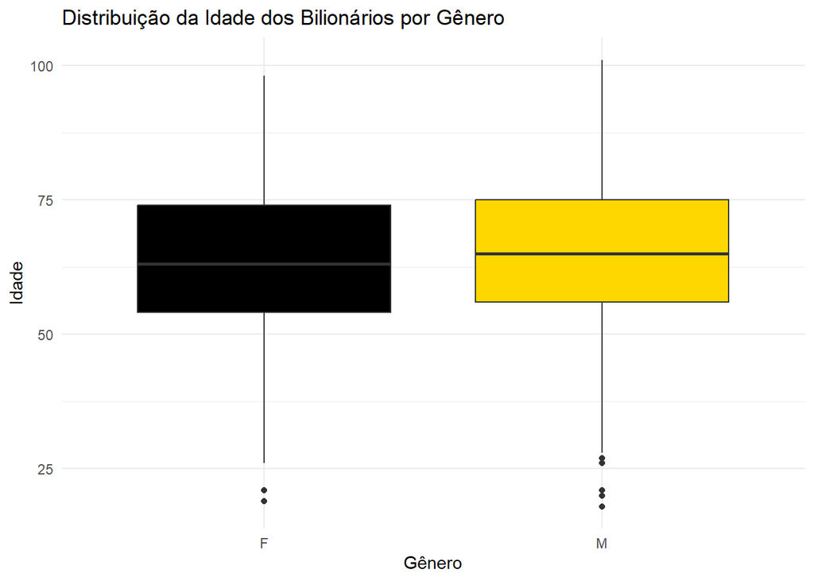

```r
ggplot(bilionario, aes(x = gender, y = age, fill = gender)) +
  geom_boxplot() +
  labs(
    title = "Distribuição da Idade dos Bilionários por Gênero",
    x = "Gênero",
    y = "Idade",
  ) +
  guides(fill = FALSE) +
  scale_fill_manual(values = c("black", "gold"), labels = c("Homens", "Mulheres")) +
  theme_minimal()
```

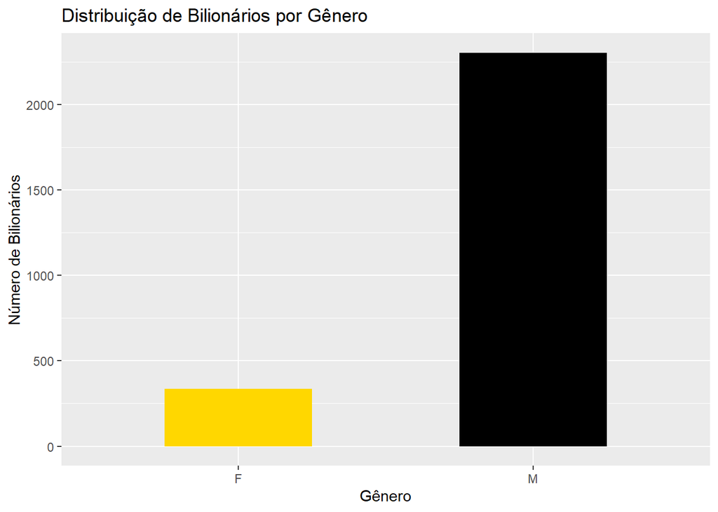

```r
# Calcular as frequências de homens e mulheres
freq <- table(bilionario$gender)

# Criar o gráfico de barras com a quantidade para ambos os gêneros
ggplot(data.frame(Gender = names(freq), Frequency = as.numeric(freq)), aes(x = Gender, y = Frequency, fill = Gender)) +
  geom_bar(stat = "identity", width = 0.5) +
  scale_fill_manual(values = c("gold", "black")) +
  labs(
    title = 'Distribuição de Bilionários por Gênero',
    x = 'Gênero',
    y = 'Número de Bilionários',
    fill = 'Gênero'
  ) +
  guides(fill = FALSE)
```

Consertando a parte de PIB

```r
# Criar variáveis dummy apenas para a variável 'category'
dados_dummies <- model.matrix(~ 0 + category, data = bilionario)

# Selecionar apenas as colunas das variáveis dummy
dados_dummies <- dados_dummies[, grepl("^category", colnames(dados_dummies))]

# Combinar as variáveis dummy com a variável 'finalWorth' em um dataframe
dados_modelo <- data.frame(dados_dummies, finalWorth = bilionario$finalWorth)

# Ajustar o modelo de regressão linear usando apenas as variáveis dummy
modelo_final <- lm(finalWorth ~ ., data = dados_modelo)

# Obter o resumo do modelo
summary(modelo_final)
```

```
##
## Call:
## lm(formula = finalWorth ~ ., data = dados_modelo)
##
## Residuals:
##    Min     1Q Median     3Q    Max
##  -6196  -3186  -1845    -45 204614
##
## Coefficients: (1 not defined because of singularities)
##                                    Estimate Std. Error t value Pr(>|t|)
## (Intercept)                          6564.5     1758.0   3.734 0.000192 ***
## categoryAutomotive                    631.4     2098.4   0.301 0.763524
## categoryConstruction...Engineering  -3931.2     2284.7  -1.721 0.085430 .
## categoryDiversified                 -1723.9     1898.2  -0.908 0.363868
## categoryEnergy                      -2029.5     2012.2  -1.009 0.313248
## categoryFashion...Retail             -178.0     1857.7  -0.096 0.923650
## categoryFinance...Investments       -2249.7     1829.8  -1.229 0.219001
## categoryFood...Beverage             -2049.4     1882.2  -1.089 0.276319
## categoryGambling...Casinos          -1744.5     2631.2  -0.663 0.507379
## categoryHealthcare                  -3364.5     1888.7  -1.781 0.074971 .
## categoryLogistics                    -577.0     2342.2  -0.246 0.805427
## categoryManufacturing               -3419.5     1840.2  -1.858 0.063255 .
## categoryMedia...Entertainment       -1866.7     2035.6  -0.917 0.359203
## categoryMetals...Mining              -526.7     2094.1  -0.252 0.801447
## categoryReal.Estate                 -3158.3     1894.0  -1.668 0.095523 .
## categoryService                     -3292.8     2213.2  -1.488 0.136929
## categorySports                      -3115.8     2355.3  -1.323 0.185986
## categoryTechnology                   -583.9     1842.8  -0.317 0.751358
## categoryTelecom                          NA         NA      NA       NA
## ---
## Signif. codes:  0 '***' 0.001 '**' 0.01 '*' 0.05 '.' 0.1 ' ' 1
##
## Residual standard error: 9788 on 2622 degrees of freedom
## Multiple R-squared:  0.0157, Adjusted R-squared:  0.009317
## F-statistic:  2.46 on 17 and 2622 DF,  p-value: 0.000764
```

```r
# Remover o caractere "$" e "," da coluna gdp_country e converter para numérico
bilionario$gdp_clean <- as.numeric(gsub("[$,]", "", bilionario$gdp_country))
# Verificar as primeiras linhas para confirmar a nova coluna
head(bilionario$gdp_clean)
```

```
## [1] 2.715518e+12 2.142770e+13 2.142770e+13 2.142770e+13 2.142770e+13
## [6] 2.142770e+13
```

```r
# Exemplo de formatação da coluna gdp_clean no dataframe bilionari
bilionario$gdp_clean <- format(as.numeric(bilionario$gdp_clean), nsmall = 3, decimal.mark = ".")

# Visualizando o resultado
head(bilionario$gdp_clean)
```

```
## [1] "2.715518e+12" "2.142770e+13" "2.142770e+13" "2.142770e+13" "2.142770e+13"
## [6] "2.142770e+13"
```

```r
# Ajuste do modelo de regressão linear
modelo <- lm(gdp_clean ~ gross_primary_education_enrollment_country + gross_tertiary_education_enrollment, data = bilionario)

# Resumo do modelo
summary(modelo)
```

```
##
## Call:
## lm(formula = gdp_clean ~ gross_primary_education_enrollment_country +
##     gross_tertiary_education_enrollment, data = bilionario)
##
## Residuals:
##        Min         1Q     Median         3Q        Max
## -2.066e+13 -9.020e+12  7.136e+12  7.136e+12  1.777e+13
##
## Coefficients:
##                                              Estimate Std. Error t value
## (Intercept)                                 6.894e+13  4.221e+12   16.33
## gross_primary_education_enrollment_country -6.182e+11  3.897e+10  -15.86
## gross_tertiary_education_enrollment         9.395e+10  8.602e+09   10.92
##                                            Pr(>|t|)
## (Intercept)                                  <2e-16 ***
## gross_primary_education_enrollment_country   <2e-16 ***
## gross_tertiary_education_enrollment          <2e-16 ***
## ---
## Signif. codes:  0 '***' 0.001 '**' 0.01 '*' 0.05 '.' 0.1 ' ' 1
##
## Residual standard error: 8.686e+12 on 2455 degrees of freedom
##   (182 observations deleted due to missingness)
## Multiple R-squared:  0.175,  Adjusted R-squared:  0.1743
## F-statistic: 260.4 on 2 and 2455 DF,  p-value: < 2.2e-16
```

```r
# Remover caracteres não numéricos de gdp_country e converter para numérico
bilionario$gdp_clean <- as.numeric(gsub("[^0-9.]", "", bilionario$gdp_clean))

# Calcular a quantidade de bilionários por país
quantidade_por_pais <- bilionario %>%
  group_by(country) %>%
  summarise(quantidade_bilionarios = n()) %>%
  left_join(bilionario %>%
              select(country, gross_primary_education_enrollment_country, gross_tertiary_education_enrollment) %>%
              distinct(),
            by = "country")
# Junção para adicionar as variáveis ao dataframe quantidade_por_pais
quantidade_por_pais <- quantidade_por_pais %>%
  left_join(bilionario %>% select(country, cpi_country) %>% distinct(), by = "country") %>%
  left_join(bilionario %>% select(country, life_expectancy_country) %>% distinct(), by = "country") %>%
  left_join(bilionario %>% select(country, total_tax_rate_country) %>% distinct(), by = "country") %>%
  left_join(bilionario %>% select(country, population_country) %>% distinct(), by = "country")


# Juntar o dataframe quantidade_por_pais com o PIB por país
quantidade_por_pais <- left_join(quantidade_por_pais, bilionario %>% select(country, gdp_clean) %>% distinct(), by = "country")

# Criar o modelo de regressão
modelo_regressao <- lm(gdp_clean ~ quantidade_bilionarios + population_country, data = quantidade_por_pais)

# Visualizar os resultados do modelo
summary(modelo_regressao)
```

```
##
## Call:
## lm(formula = gdp_clean ~ quantidade_bilionarios + population_country,
##     data = quantidade_por_pais)
##
## Residuals:
##     Min      1Q  Median      3Q     Max
## -2.5535 -1.5072 -0.3937  0.9632  5.5036
##
## Coefficients:
##                          Estimate Std. Error t value Pr(>|t|)
## (Intercept)             3.615e+00  2.491e-01  14.512   <2e-16 ***
## quantidade_bilionarios -1.137e-03  2.627e-03  -0.433    0.667
## population_country     -9.696e-10  1.236e-09  -0.785    0.435
## ---
## Signif. codes:  0 '***' 0.001 '**' 0.01 '*' 0.05 '.' 0.1 ' ' 1
##
## Residual standard error: 1.913 on 65 degrees of freedom
##   (11 observations deleted due to missingness)
## Multiple R-squared:  0.02817,    Adjusted R-squared:  -0.001733
## F-statistic: 0.942 on 2 and 65 DF,  p-value: 0.3951
```

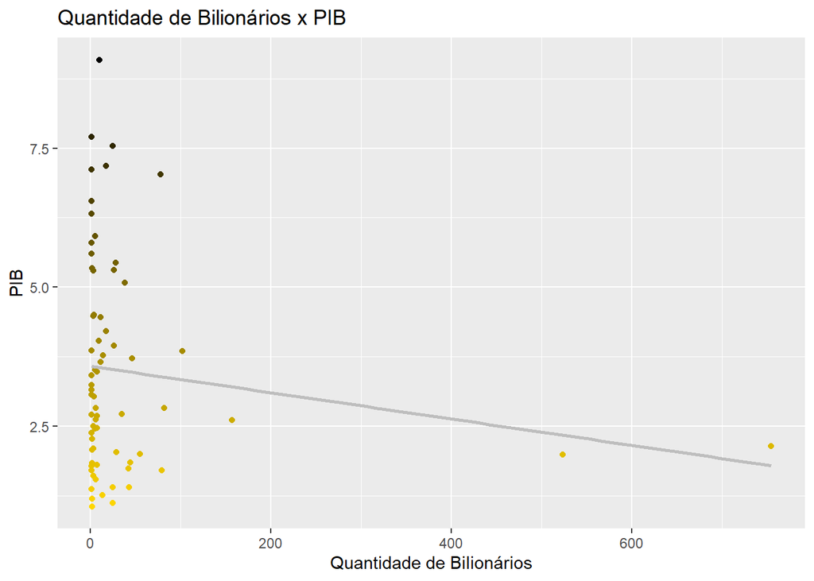

```r
# Criar uma paleta de cores gradativa de dourado a preto
cores <- colorRampPalette(c("gold", "black"))(nrow(quantidade_por_pais))

# Criar o gráfico de dispersão com cores diferenciadas para maiores e menores valores de PIB
quant_pib <- ggplot(quantidade_por_pais, aes(x = quantidade_bilionarios, y = gdp_clean, color = gdp_clean)) +
  geom_point(size = 1.5) +
  labs(x = "Quantidade de Bilionários", y = "PIB") +
  ggtitle("Quantidade de Bilionários x PIB") +
  scale_y_continuous(labels = label_number_si(suffix = "")) +
  scale_color_gradientn(colors = cores) +
  geom_smooth(method = "lm", se = FALSE, color = "gray") +
  guides(color = FALSE)
# Exibir o gráfico
print(quant_pib)
```

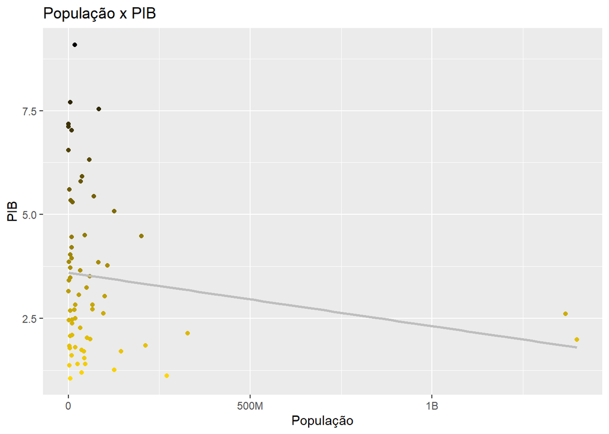

```r
# Criar uma paleta de cores gradativa de dourado a preto
cores <- colorRampPalette(c("gold", "black"))(nrow(quantidade_por_pais))

# Criar o gráfico de dispersão com cores diferenciadas para maiores e menores valores de PIB
quant_pib <- ggplot(quantidade_por_pais, aes(x = population_country, y = gdp_clean, color = gdp_clean)) +
  geom_point(size = 1.5) +
  labs(x = "População", y = "PIB") +
  ggtitle("População x PIB") +
  scale_y_continuous(labels = label_number_si(suffix = "")) +
  scale_x_continuous(labels = label_number_si(suffix = "")) +
  scale_color_gradientn(colors = cores) +
  geom_smooth(method = "lm", se = FALSE, color = "gray") +
  guides(color = FALSE)

# Exibir o gráfico
print(quant_pib)
```

Gráfico de dispersão entre expectativa de vida e quantidade de bilionários no país

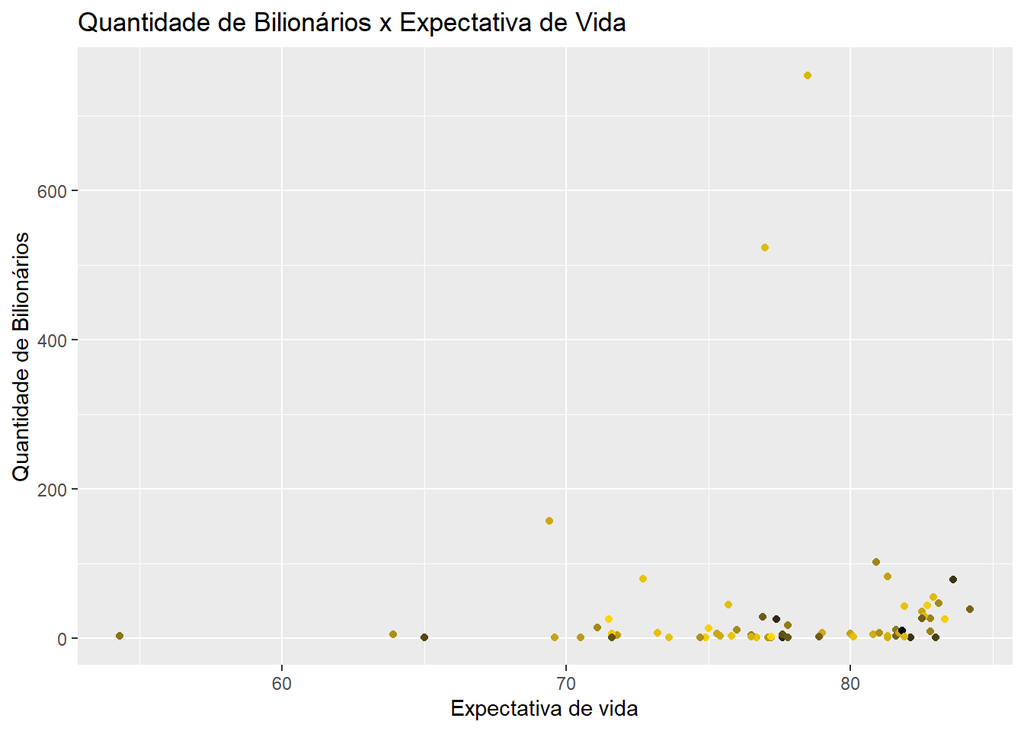

```r
# Criar o gráfico de dispersão com cores diferenciadas para maiores e menores valores de PIB
quant_pib <- ggplot(quantidade_por_pais, aes(x = life_expectancy_country, y = quantidade_bilionarios, color = gdp_clean)) +
  geom_point(size = 1.5) +
  labs(x = "Expectativa de vida", y = "Quantidade de Bilionários") +
  ggtitle("Quantidade de Bilionários x Expectativa de Vida") +
    scale_color_gradient(low = "gold", high = "black") +
  guides(color = FALSE)

# Exibir o gráfico
print(quant_pib)
```

Calculando o spearman das variaveis acima

```r
# Criando o novo dataframe com as colunas 'finalWorth' e 'age'
bilionariospearman2 <- data.frame(
  life_expectancy_country = as.numeric(quantidade_por_pais$life_expectancy_country),
  quantidade_bilionarios = as.numeric(quantidade_por_pais$quantidade_bilionarios)
)

 #Removendo NA em age
sum(is.na(bilionariospearman2$life_expectancy_country))
```

```
## [1] 13
```

```r
sum(is.na(bilionariospearman2$quantidade_bilionarios))
```

```
## [1] 0
```

```r
bilionariospearman2 <- bilionariospearman2[!is.na(bilionariospearman2$life_expectancy_country), ]

# Calculando a correlação de Spearman
correlacao_spearman2 <- cor(bilionariospearman2$life_expectancy_country, bilionariospearman2$quantidade_bilionarios, method = "spearman")


# Exibindo o resultado
print(correlacao_spearman2)
```

```
## [1] 0.3187218
```

Gráfico de dispersão entre ensino superior e quantidade de bilionários no país

[figure not shown]

```r
# Criar o gráfico de dispersão com cores diferenciadas para maiores e menores valores de PIB
quant_pib <- ggplot(quantidade_por_pais, aes(x = gross_tertiary_education_enrollment , y = quantidade_bilionarios, color = gdp_clean)) +
  geom_point(size = 1.5) +
  labs(x = "Matrículas no Ensino Superior (em milhões)", y = "Quantidade de Bilionários") +
  ggtitle("Quantidade de Bilionários x Matrículas no Ensino Superior") +
    scale_color_gradient(low = "gold", high = "black") +
  guides(color = FALSE)

# Exibir o gráfico
print(quant_pib)
```

```r
# Criando o novo dataframe com as colunas 'finalWorth' e 'age'
bilionariospearman3 <- data.frame(
  gross_tertiary_education_enrollment  = as.numeric(quantidade_por_pais$gross_tertiary_education_enrollment),
    gross_primary_education_enrollment_country   = as.numeric(quantidade_por_pais$gross_primary_education_enrollment_country ),
  quantidade_bilionarios = as.numeric(quantidade_por_pais$quantidade_bilionarios)
)

 #Removendo NA em age
sum(is.na(bilionariospearman3$gross_primary_education_enrollment_country))
```

```
## [1] 12
```

```r
sum(is.na(bilionariospearman3$gross_tertiary_education_enrollment))
```

```
## [1] 13
```

```r
sum(is.na(bilionariospearman3$quantidade_bilionarios))
```

```
## [1] 0
```

```r
bilionariospearman3 <- bilionariospearman3[!is.na(bilionariospearman3$gross_tertiary_education_enrollment), ]

# Calculando a correlação de Spearman
correlacao_spearman3 <- cor(bilionariospearman3$gross_tertiary_education_enrollment, bilionariospearman3$quantidade_bilionarios, method = "spearman")

# Exibindo o resultado
print(correlacao_spearman3)
```

```
## [1] 0.3179955
```

```r
# Tabela de contingência entre 'gender' e 'category'
tabela_contingencia <- table(bilionario$gender, bilionario$category)

# Exibir a tabela de contingência
print(tabela_contingencia)
```

```
##
##     Automotive Construction & Engineering Diversified Energy Fashion & Retail
##   F          7                          6          29     10               39
##   M         66                         39         158     90              227
##
##     Finance & Investments Food & Beverage Gambling & Casinos Healthcare
##   F                    30              45                  4         28
##   M                   342             167                 21        173
##
##     Logistics Manufacturing Media & Entertainment Metals & Mining Real Estate
##   F         6            45                    12               9          22
##   M        34           279                    79              65         171
##
##     Service Sports Technology Telecom
##   F       9      6         30       0
##   M      44     33        284      31
```

```r
# Teste qui-quadrado de independência
teste_qui_quadrado <- chisq.test(tabela_contingencia)
print(teste_qui_quadrado)
```

```
##
##  Pearson's Chi-squared test
##
## data:  tabela_contingencia
## X-squared = 34.414, df = 17, p-value = 0.007421
```

```r
# Calcular o coeficiente de contingência
coef_contingencia <- sqrt(chisq.test(tabela_contingencia)$statistic / sum(tabela_contingencia) * (min(dim(tabela_contingencia)) - 1))
# Exibir o coeficiente de contingência
print(coef_contingencia)
```

```
## X-squared
##  0.114173
```

[figure not shown]

```r
educacao_expectativa <- ggplot(bilionario, aes(x = gross_primary_education_enrollment_country, y = life_expectancy_country)) +
  geom_point(aes(color = finalWorth), size = 1.5) +
  labs(title = "Educação primária vs. Patrimônio de Bilionários", x = "Educação Primária", y = "Patrimônio líquido em milhões ($USD)") +
  theme_minimal() +
  scale_color_gradient(low = "gold", high = "black") +
  guides(color = FALSE)

print(educacao_expectativa)
```

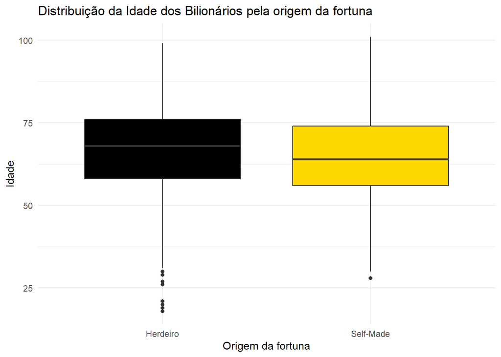

```r
ggplot(bilionario, aes(x = selfMade, y = age, fill = selfMade)) +
  geom_boxplot() +
   scale_x_discrete(labels = c("Herdeiro", "Self-Made")) +
  labs(
    title = "Distribuição da Idade dos Bilionários pela origem da fortuna",
    x = "Origem da fortuna",
    y = "Idade"
  ) +
  guides(fill = FALSE) +
  scale_fill_manual(values = c("black", "gold"), labels = c("Herdeiro", "Self-Made")) +
  theme_minimal()
```

```r
#Finalização
bilionarios_selfmade <- subset(bilionario, selfMade == TRUE)
contagem_por_genero <- table(bilionarios_selfmade$gender)

# Exibindo a contagem por gênero
table(contagem_por_genero)
```

[output not shown]

```
## < table of extent 0 >
```

```r
# Realizando a regressão linear simples
modelo <- lm(age ~ selfMade , data = bilionario)

# Sumário do modelo
summary(modelo)
```

```
##
## Call:
## lm(formula = age ~ selfMade, data = bilionario)
##
## Residuals:
##     Min      1Q  Median      3Q     Max
## -48.150  -8.696  -0.150   9.304  36.304
##
## Coefficients:
##                   Estimate Std. Error t value Pr(>|t|)
## (Intercept)        66.1499     0.4721 140.122   <2e-16 ***
## selfMadeSelf-Made  -1.4542     0.5665  -2.567   0.0103 *
## ---
## Signif. codes:  0 '***' 0.001 '**' 0.01 '*' 0.05 '.' 0.1 ' ' 1
##
## Residual standard error: 13.24 on 2573 degrees of freedom
##   (65 observations deleted due to missingness)
## Multiple R-squared:  0.002554,   Adjusted R-squared:  0.002166
## F-statistic: 6.588 on 1 and 2573 DF,  p-value: 0.01032
```

```r
kable(quantidade_por_pais)
```

| country | quantidade_bilionarios | gross_primary_education_enrollment_country | gross_tertiary_education_enrollment | cpi_country | life_expectancy_country | total_tax_rate_country | population_country | gdp_clean |
| --- | --- | --- | --- | --- | --- | --- | --- | --- |
|  | 38 | NA | NA | NA | NA | NA | NA | NA |
| Algeria | 1 | 109.9 | 51.4 | 151.36 | 76.7 | 66.1 | 43053054 | 1.699882 |
| Andorra | 1 | 106.4 | NA | NA | NA | NA | 77142 | 3.154058 |
| Argentina | 4 | 109.7 | 90.0 | 232.75 | 76.5 | 106.3 | 44938712 | 4.496634 |
| Armenia | 1 | 92.7 | 54.6 | 129.18 | 74.9 | 22.6 | 2957731 | 1.367280 |
| Australia | 43 | 100.3 | 113.1 | 119.80 | 82.7 | 47.4 | 25766605 | 1.392681 |
| Austria | 11 | 103.1 | 85.1 | 118.06 | 81.6 | 51.4 | 8877067 | 4.463147 |
| Bahamas | 2 | NA | NA | NA | NA | NA | NA | NA |
| Bahrain | 1 | 99.4 | 50.5 | 117.59 | 77.2 | 13.8 | 1501635 | 3.857407 |
| Belgium | 3 | 103.9 | 79.7 | 117.11 | 81.6 | 55.4 | 11484055 | 5.296067 |
| Bermuda | 2 | NA | NA | NA | NA | NA | NA | NA |
| Brazil | 44 | 115.4 | 51.3 | 167.40 | 75.7 | 65.1 | 212559417 | 1.839758 |
| British Virgin Islands | 1 | NA | NA | NA | NA | NA | NA | NA |
| Cambodia | 1 | 107.4 | 13.7 | 127.63 | 69.6 | 23.1 | 16486542 | 2.708939 |
| Canada | 42 | 100.9 | 68.9 | 116.76 | 81.9 | 24.5 | 36991981 | 1.736426 |
| Cayman Islands | 3 | NA | NA | NA | NA | NA | NA | NA |
| Chile | 6 | 101.4 | 88.5 | 131.91 | 80.0 | 34.0 | 18952038 | 2.823182 |
| China | 523 | 100.2 | 50.6 | 125.08 | 77.0 | 59.2 | 1397715000 | 1.991000 |
| Colombia | 1 | 114.5 | 55.3 | 140.95 | 77.1 | 71.2 | 50339443 | 3.238028 |
| Cyprus | 5 | 99.3 | 75.9 | 102.51 | 80.8 | 22.4 | 1198575 | 2.456465 |
| Czech Republic | 7 | 100.7 | 64.1 | 116.48 | 79.0 | 46.1 | 10669709 | 2.464892 |
| Denmark | 7 | 101.3 | 80.6 | 110.35 | 81.0 | 23.8 | 5818553 | 3.480780 |
| Egypt | 4 | 106.3 | 35.2 | 288.57 | 71.8 | 44.4 | 100388073 | 3.031751 |
| Eswatini (Swaziland) | 1 | NA | NA | NA | NA | NA | NA | NA |
| Finland | 7 | 100.2 | 88.2 | 112.33 | 81.7 | 36.6 | 5520314 | 2.687612 |
| France | 35 | 102.5 | 65.6 | 110.05 | 82.5 | 60.7 | 67059887 | 2.715518 |
| Georgia | 1 | 98.6 | 63.9 | 133.61 | 73.6 | 9.9 | 3720382 | 1.774320 |
| Germany | 102 | 104.0 | 70.2 | 112.85 | 80.9 | 48.8 | 83132799 | 3.845630 |
| Greece | 3 | 99.6 | 136.6 | 101.87 | 81.3 | 51.9 | 10716322 | 2.098528 |
| Guernsey | 1 | NA | NA | NA | NA | NA | NA | NA |
| Hong Kong | 68 | NA | NA | NA | NA | NA | NA | NA |
| Hungary | 3 | 100.8 | 48.5 | 121.64 | 75.8 | 37.9 | 9769949 | 1.609672 |
| India | 157 | 113.0 | 28.1 | 180.44 | 69.4 | 49.7 | 1366417754 | 2.611000 |
| Indonesia | 25 | 106.4 | 36.3 | 151.18 | 71.5 | 30.1 | 270203917 | 1.119191 |
| Ireland | 4 | NA | NA | NA | NA | NA | NA | NA |
| Israel | 26 | 104.9 | 63.4 | 108.15 | 82.8 | 25.3 | 9053300 | 3.950987 |
| Italy | 55 | 101.9 | 61.9 | 110.62 | 82.9 | 59.1 | 60297396 | 2.001244 |
| Japan | 38 | 98.8 | 63.2 | 105.48 | 84.2 | 46.7 | 126226568 | 5.081770 |
| Kazakhstan | 7 | 104.4 | 61.7 | 182.75 | 73.2 | 28.4 | 18513930 | 1.801617 |
| Latvia | 1 | 99.4 | 88.1 | 116.86 | 74.7 | 38.1 | 1912789 | 3.411720 |
| Lebanon | 2 | 95.1 | 26.3 | 130.02 | 78.9 | 32.2 | 6855713 | 5.336704 |
| Liechtenstein | 1 | 104.7 | 35.6 | NA | 83.0 | 21.6 | 38019 | 6.552859 |
| Luxembourg | 1 | 102.3 | 19.2 | 115.09 | 82.1 | 20.4 | 645397 | 7.110492 |
| Malaysia | 11 | 105.3 | 45.1 | 121.46 | 76.0 | 38.7 | 32447385 | 3.647015 |
| Mexico | 13 | 105.8 | 40.2 | 141.54 | 75.0 | 55.1 | 126014024 | 1.258287 |
| Monaco | 17 | NA | NA | NA | NA | NA | 38964 | 7.184844 |
| Morocco | 2 | 113.9 | 35.9 | 111.07 | 76.5 | 45.8 | 36910560 | 1.187253 |
| Nepal | 1 | 142.1 | 12.4 | 188.73 | 70.5 | 41.8 | 28608710 | 3.064138 |
| Netherlands | 10 | 104.2 | 85.0 | 115.91 | 81.8 | 41.2 | 17332850 | 9.090704 |
| New Zealand | 2 | 100.0 | 82.0 | 114.24 | 81.9 | 34.6 | 4841000 | 2.069288 |
| Nigeria | 3 | 84.7 | 10.2 | 267.51 | 54.3 | 34.8 | 200963599 | 4.481204 |
| Norway | 9 | 100.3 | 82.0 | 120.27 | 82.8 | 36.2 | 5347896 | 4.033364 |
| Oman | 1 | 103.4 | 38.0 | 113.53 | 77.6 | 27.4 | 5266535 | 7.698309 |
| Peru | 2 | 106.9 | 70.7 | 129.78 | 76.5 | 36.8 | 32510453 | 2.268481 |
| Philippines | 14 | 107.5 | 35.5 | 129.61 | 71.1 | 43.1 | 108116615 | 3.767955 |
| Poland | 5 | 100.0 | 67.8 | 114.11 | 77.6 | 40.8 | 37970874 | 5.921644 |
| Portugal | 1 | 106.2 | 63.9 | 110.62 | 81.3 | 39.8 | 10269417 | 2.376861 |
| Qatar | 2 | 103.8 | 17.9 | 115.38 | 80.1 | 11.3 | 2832067 | 1.834662 |
| Romania | 3 | 85.2 | 49.4 | 123.78 | 75.4 | 20.0 | 19356544 | 2.500774 |
| Russia | 79 | 102.6 | 81.9 | 180.75 | 72.7 | 46.2 | 144373535 | 1.699877 |
| Singapore | 46 | 100.6 | 84.8 | 114.41 | 83.1 | 21.0 | 5703569 | 3.720625 |
| Slovakia | 2 | 98.7 | 46.6 | 115.34 | 77.2 | 49.7 | 5454073 | 1.054223 |
| South Africa | 5 | 100.9 | 22.4 | 158.93 | 63.9 | 29.2 | 58558270 | 3.514316 |
| South Korea | 29 | 98.1 | 94.3 | 115.16 | 82.6 | 33.2 | 51709098 | 2.029000 |
| Spain | 25 | 102.7 | 88.9 | 110.96 | 83.3 | 47.0 | 47076781 | 1.394116 |
| Sweden | 26 | 126.6 | 67.0 | 110.51 | 82.5 | 49.1 | 10285453 | 5.308329 |
| Switzerland | 78 | 105.2 | 59.6 | 99.55 | 83.6 | 28.8 | 8574832 | 7.030824 |
| Taiwan | 43 | NA | NA | NA | NA | NA | NA | NA |
| Tanzania | 1 | 94.2 | 4.0 | 187.43 | 65.0 | 43.8 | 58005463 | 6.317707 |
| Thailand | 28 | 99.8 | 49.3 | 113.27 | 76.9 | 29.5 | 69625582 | 5.436500 |
| Turkey | 25 | 93.2 | 23.9 | 234.44 | 77.4 | 42.3 | 83429615 | 7.544117 |
| Turks and Caicos Islands | 1 | NA | NA | NA | NA | NA | NA | NA |
| Ukraine | 6 | 99.0 | 82.7 | 281.66 | 71.6 | 45.2 | 44385155 | 1.537811 |
| United Arab Emirates | 17 | 108.4 | 36.8 | 114.52 | 77.8 | 15.9 | 9770529 | 4.211423 |
| United Kingdom | 82 | 101.2 | 60.0 | 119.62 | 81.3 | 30.6 | 66834405 | 2.827113 |
| United States | 754 | 101.8 | 88.2 | 117.24 | 78.5 | 36.6 | 328239523 | 2.142770 |
| Uruguay | 1 | 108.5 | 63.1 | 202.92 | 77.8 | 41.8 | 3461734 | 5.604591 |
| Uzbekistan | 1 | 104.2 | 10.1 | NA | 71.6 | 31.6 | 33580650 | 5.792129 |
| Vietnam | 6 | 110.6 | 28.5 | 163.52 | 75.3 | 37.6 | 96462106 | 2.619212 |

```r
# Lista com os valores
valores <- c(169988236398, 3154057987, 449663446954, 13672802158, 1392680589329, 446314739528,
             38574069149, 529606710418, 1839758040766, 27089389787, 1736425629520, 282318159745,
             19910000000000, 323802808108, 24564647935, 246489245495, 348078018464, 303175127598,
             268761201365, 2715518274227, 17743195770, 3845630030824, 209852761469, 160967157504,
             2611000000000, 1119190780753, 395098666122, 2001244392042, 5081769542380, 180161741180,
             34117202555, 53367042272, 6552858739, 71104919108, 364701517788, 1258286717125, 7184844193,
             118725279596, 30641380604, 909070395161, 206928765544, 448120428859, 403336363636, 76983094928,
             226848050820, 376795508680, 592164400688, 237686075635, 183466208791, 250077444017, 1699876578871,
             372062527489, 105422304976, 351431649241, 2029000000000, 1394116310769, 530832908738, 703082435360,
             63177068175, 543649976166, 754411708203, 153781069118, 421142267938, 2827113184696, 21427700000000,
             56045912952, 57921286440, 261921244843)

# Função para formatar os valores
formatar_valores <- function(valores) {
  valores_formatados <- character(length(valores))
  for (i in seq_along(valores)) {
    if (abs(valores[i]) >= 1e12) {
      valor <- valores[i] / 1e12
      valores_formatados[i] <- paste0(format(valor, nsmall = 12, decimal.mark = "."))
    } else {
      valores_formatados[i] <- paste0("0,", format(abs(valores[i]), nsmall = 12, digits = 15, trim = TRUE, decimal.mark = "."))
    }
  }
  return(valores_formatados)
}
# Chamando a função para formatar os valores
valores_formatados <- formatar_valores(valores)

# Exibindo os valores formatados
kable(valores_formatados)
```

[output not shown]

```r
kable(quantidade_por_pais)
```

[output not shown]